# $\chi^2$ tests and joining data frames

### Homework 6

INFO 5871-0014

*Keke Wu*

```python
import pandas as pd
import numpy as np
%matplotlib inline
import matplotlib.pyplot as plt
import seaborn as sns
import scipy.stats as st
```

## Question 1: Create a unified data frame

Some of this is similar to `inclass06`.

### Load data frames

Drop the `Total`, `Cargo`, and `Grand Total` columns.

```python
flt_df = pd.read_csv('den_flights.csv')
flt_df.drop(['Total','Cargo','Grand Total'], axis=1, inplace=True)
flt_df.head()
```

|  | Month | American | Delta | Frontier | Other | Southwest | United | United Express |
| --- | --- | --- | --- | --- | --- | --- | --- | --- |
| 0 | 1995-02-01 | 64 | 51 | 28 | 251 | NaN | 561 | 210 |
| 1 | 1995-03-01 | 2228 | 1745 | 844 | 6403 | NaN | 20016 | 8072 |
| 2 | 1995-04-01 | 2106 | 1664 | 815 | 5130 | NaN | 18743 | 6762 |
| 3 | 1995-05-01 | 2186 | 1788 | 900 | 4747 | NaN | 19578 | 7141 |
| 4 | 1995-06-01 | 2194 | 1786 | 880 | 4531 | NaN | 18887 | 7657 |

```python
pas_df = pd.read_csv('den_passengers.csv')
pas_df.drop(['Total','Cargo','Grand Total'], axis=1, inplace=True)
pas_df.head()
```

|  | Month | American | Delta | Frontier | Other | Southwest | United | United Express |
| --- | --- | --- | --- | --- | --- | --- | --- | --- |
| 0 | 1995-02-01 | 5833 | 4805 | 1434 | 8625 | NaN | 47230 | 2635 |
| 1 | 1995-03-01 | 228196 | 200964 | 36703 | 245171 | NaN | 1962445 | 169190 |
| 2 | 1995-04-01 | 184229 | 157853 | 40050 | 191393 | NaN | 1724836 | 124351 |
| 3 | 1995-05-01 | 187990 | 162622 | 41403 | 171425 | NaN | 1833305 | 135800 |
| 4 | 1995-06-01 | 229348 | 198499 | 43754 | 186030 | NaN | 1975754 | 170033 |

### Convert Month column to date object and set as the index

```python
flt_df.Month = pd.to_datetime(flt_df.Month)
flt_df = flt_df.set_index('Month')
```

```python
pas_df.Month = pd.to_datetime(pas_df.Month)
pas_df = pas_df.set_index('Month')
```

### Remove partial years using `loc`

```python
flt_df = flt_df.loc['1996-01-01':'2018-12-01']
pas_df = pas_df.loc['1996-01-01':'2018-12-01']
```

```python
flt_df.head()
```

| Month | American | Delta | Frontier | Other | Southwest | United | United Express |
| --- | --- | --- | --- | --- | --- | --- | --- |
| 1996-01-01 | 2002 | 1710 | 1256 | 2993 | NaN | 18180 | 8361 |
| 1996-02-01 | 1958 | 1606 | 1132 | 2878 | NaN | 18216 | 7957 |
| 1996-03-01 | 2128 | 1730 | 1221 | 3110 | NaN | 19789 | 8330 |
| 1996-04-01 | 1928 | 1634 | 1206 | 2830 | NaN | 18501 | 7261 |
| 1996-05-01 | 1879 | 1684 | 1248 | 2721 | NaN | 19064 | 7284 |

```python
pas_df.head()
```

| Month | American | Delta | Frontier | Other | Southwest | United | United Express |
| --- | --- | --- | --- | --- | --- | --- | --- |
| 1996-01-01 | 190913 | 187742 | 85574 | 110799 | NaN | 1722852 | 177437 |
| 1996-02-01 | 185774 | 188882 | 77753 | 132357 | NaN | 1730614 | 183843 |
| 1996-03-01 | 235231 | 220495 | 100527 | 158944 | NaN | 2062532 | 194721 |
| 1996-04-01 | 172746 | 179340 | 85674 | 120648 | NaN | 1758331 | 138287 |
| 1996-05-01 | 171146 | 187344 | 90060 | 121000 | NaN | 1890598 | 139383 |

### Rename the columns so that the flight data and the passenger data are distinguished

Use `f` and a list comprehension

```python
pas_df.columns = [f"{col}_Passenger" for col in pas_df.columns]
pas_df.head()
```

| Month | American_Passenger | Delta_Passenger | Frontier_Passenger | Other_Passenger | Southwest_Passenger | United_Passenger | United Express_Passenger |
| --- | --- | --- | --- | --- | --- | --- | --- |
| 1996-01-01 | 190913 | 187742 | 85574 | 110799 | NaN | 1722852 | 177437 |
| 1996-02-01 | 185774 | 188882 | 77753 | 132357 | NaN | 1730614 | 183843 |
| 1996-03-01 | 235231 | 220495 | 100527 | 158944 | NaN | 2062532 | 194721 |
| 1996-04-01 | 172746 | 179340 | 85674 | 120648 | NaN | 1758331 | 138287 |
| 1996-05-01 | 171146 | 187344 | 90060 | 121000 | NaN | 1890598 | 139383 |

```python
flt_df.columns = [f"{col}_Flight" for col in flt_df.columns]
flt_df.head()
```

| Month | American_Flight | Delta_Flight | Frontier_Flight | Other_Flight | Southwest_Flight | United_Flight | United Express_Flight |
| --- | --- | --- | --- | --- | --- | --- | --- |
| 1996-01-01 | 2002 | 1710 | 1256 | 2993 | NaN | 18180 | 8361 |
| 1996-02-01 | 1958 | 1606 | 1132 | 2878 | NaN | 18216 | 7957 |
| 1996-03-01 | 2128 | 1730 | 1221 | 3110 | NaN | 19789 | 8330 |
| 1996-04-01 | 1928 | 1634 | 1206 | 2830 | NaN | 18501 | 7261 |
| 1996-05-01 | 1879 | 1684 | 1248 | 2721 | NaN | 19064 | 7284 |

### Join into a single data frame using `concat`

```python
df = pd.concat([pas_df, flt_df], axis=1)
print(df.shape)
df.head()
```

```
(277, 14)
```

| Month | American_Passenger | Delta_Passenger | Frontier_Passenger | Other_Passenger | Southwest_Passenger | United_Passenger | United Express_Passenger | American_Flight | Delta_Flight | Frontier_Flight | Other_Flight | Southwest_Flight | United_Flight | United Express_Flight |
| --- | --- | --- | --- | --- | --- | --- | --- | --- | --- | --- | --- | --- | --- | --- |
| 1996-01-01 | 190913 | 187742 | 85574 | 110799 | NaN | 1722852 | 177437 | 2002 | 1710 | 1256 | 2993 | NaN | 18180 | 8361 |
| 1996-02-01 | 185774 | 188882 | 77753 | 132357 | NaN | 1730614 | 183843 | 1958 | 1606 | 1132 | 2878 | NaN | 18216 | 7957 |
| 1996-03-01 | 235231 | 220495 | 100527 | 158944 | NaN | 2062532 | 194721 | 2128 | 1730 | 1221 | 3110 | NaN | 19789 | 8330 |
| 1996-04-01 | 172746 | 179340 | 85674 | 120648 | NaN | 1758331 | 138287 | 1928 | 1634 | 1206 | 2830 | NaN | 18501 | 7261 |
| 1996-05-01 | 171146 | 187344 | 90060 | 121000 | NaN | 1890598 | 139383 | 1879 | 1684 | 1248 | 2721 | NaN | 19064 | 7284 |

## Question 2: Work with passenger load information

### Create a new data frame passenger load

This is the # of passengers per flight (passengers / flights). Build the data frame by creating a dictionary first. Iterate through the airline names and create a new Series for the passenger load.

```python
load_dict = {}

load_American = df['American_Passenger']/df['American_Flight']
load_Delta = df['Delta_Passenger']/df['Delta_Flight']
load_Frontier = df['Frontier_Passenger']/df['Frontier_Flight']
load_Other = df['Other_Passenger']/df['Other_Flight']
load_Southwest = df['Southwest_Passenger']/df['Southwest_Flight']
load_United = df['United_Passenger']/df['United_Flight']
load_UE = df['United Express_Passenger']/df['United Express_Flight']

load_dict['American'] = load_American
load_dict['Dealta'] = load_Delta
load_dict['Frontier'] = load_Frontier
load_dict['Other'] = load_Other
load_dict['Southwest'] = load_Southwest
load_dict['United'] = load_United
load_dict['United Express'] = load_UE
load_df = pd.DataFrame(load_dict)
load_df.head()
```

| Month | American | Dealta | Frontier | Other | Southwest | United | United Express |
| --- | --- | --- | --- | --- | --- | --- | --- |
| 1996-01-01 | 95.361139 | 109.790643 | 68.132166 | 37.019379 | NaN | 94.766337 | 21.221983 |
| 1996-02-01 | 94.879469 | 117.610212 | 68.686396 | 45.989229 | NaN | 95.005160 | 23.104562 |
| 1996-03-01 | 110.540883 | 127.453757 | 82.331695 | 51.107395 | NaN | 104.226186 | 23.375870 |
| 1996-04-01 | 89.598548 | 109.755202 | 71.039801 | 42.631802 | NaN | 95.039782 | 19.045173 |
| 1996-05-01 | 91.083555 | 111.249406 | 72.163462 | 44.468945 | NaN | 99.171108 | 19.135502 |

### Drop Other, United Express, and Frontier

They fly smaller planes and look very different by this measure

```python
load_df.drop(['Other','United Express', 'Frontier'],axis=1,inplace=True)
load_df.head()
```

| Month | American | Dealta | Southwest | United |
| --- | --- | --- | --- | --- |
| 1996-01-01 | 95.361139 | 109.790643 | NaN | 94.766337 |
| 1996-02-01 | 94.879469 | 117.610212 | NaN | 95.005160 |
| 1996-03-01 | 110.540883 | 127.453757 | NaN | 104.226186 |
| 1996-04-01 | 89.598548 | 109.755202 | NaN | 95.039782 |
| 1996-05-01 | 91.083555 | 111.249406 | NaN | 99.171108 |

### Plot the load over time

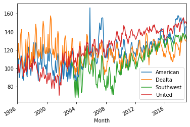

```python
load_df.plot();
```

### Create a boxplot of these values

See attached PNG file

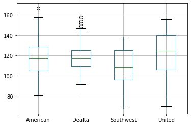

```python
load_df.boxplot();
```

### Compute average load for each airline. Which is the highest?

```python
avload_American = load_df['American'].sum()/load_df.shape[0]
print(f"American: {avload_American}")
avload_Delta = load_df['Dealta'].sum()/load_df.shape[0]
print(f"Delta: {avload_Delta}")
avload_Southwest = load_df['Southwest'].sum()/load_df.shape[0]
print(f"Southwest: {avload_Southwest}")
avload_United = load_df['United'].sum()/load_df.shape[0]
print(f"United: {avload_United}")
```

```
American: 117.56493079175132
Delta: 117.72087362086712
Southwest: 74.20102130938302
United: 121.73849188005542
```

## Question 3: Seasonal variation

We are back to using the flight count data frame for this part

## Create a Series with the total number of flights each month in 2006

Hint: The total for January should be 45,462

```python
flt_df['Total Flights'] = flt_df.sum(axis=1)
month_filter = (flt_df.index > '2005-12-01') & (flt_df.index < '2007-01-01')
total_flights_2006 = flt_df.loc[month_filter]
total_flights_2006
```

| Month | American_Flight | Delta_Flight | Frontier_Flight | Other_Flight | Southwest_Flight | United_Flight | United Express_Flight | Total Flights |
| --- | --- | --- | --- | --- | --- | --- | --- | --- |
| 2006-01-01 | 1772 | 1732 | 8786 | 7035 | 959.0 | 13975 | 11203 | 45462.0 |
| 2006-02-01 | 1572 | 1534 | 7915 | 6318 | 924.0 | 13351 | 10413 | 42027.0 |
| 2006-03-01 | 1706 | 1800 | 8967 | 6914 | 1418.0 | 15369 | 11544 | 47718.0 |
| 2006-04-01 | 1712 | 1632 | 8726 | 6461 | 1414.0 | 14376 | 10660 | 44981.0 |
| 2006-05-01 | 1880 | 1620 | 9592 | 6784 | 1464.0 | 15943 | 11355 | 48638.0 |
| 2006-06-01 | 1858 | 1624 | 9511 | 6899 | 1454.0 | 15538 | 12267 | 49151.0 |
| 2006-07-01 | 1924 | 1688 | 9870 | 7157 | 1614.0 | 15806 | 13145 | 51204.0 |
| 2006-08-01 | 1916 | 1688 | 9803 | 7251 | 2152.0 | 16175 | 13351 | 52336.0 |
| 2006-09-01 | 1790 | 1546 | 9236 | 6510 | 2088.0 | 14649 | 11816 | 47635.0 |
| 2006-10-01 | 1856 | 1586 | 9534 | 6760 | 2169.0 | 14948 | 11730 | 48583.0 |
| 2006-11-01 | 1754 | 1544 | 8939 | 6221 | 2068.0 | 13881 | 11283 | 45690.0 |
| 2006-12-01 | 1670 | 1458 | 8455 | 5925 | 2034.0 | 13450 | 10625 | 43617.0 |

### Create a bar plot of the monthly values

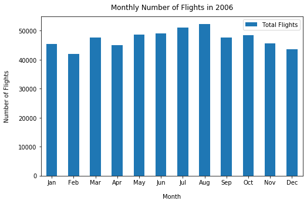

```python
ax = total_flights_2006.plot.bar(y='Total Flights', figsize=(8, 5), rot=0)

N = 12
ind = np.arange(N)
plt.xticks(ind, ('Jan', 'Feb', 'Mar', 'Apr', 'May','Jun', 'Jul', 'Aug', 'Sep', 'Oct','Nov','Dec'))
plt.xlabel("Month", labelpad=14)
plt.ylabel("Number of Flights", labelpad=14)
plt.title("Monthly Number of Flights in 2006", y=1.02);
```

### Calculate the monthly # of flights if they were equally distributed

Hint: should be around 47,253

```python
flights_exp = total_flights_2006['Total Flights'].sum()/12
flights_exp
```

```
47253.5
```

## Question 4: Assessing seasonal variation

Using the $\chi^2$ method, determine if this observed seasonal variation is statistically significant.

### What is the null hypothesis?

*H0: The observed seasonal variation is a random sample, there is no significant seasonal variation between the observed value and the expected value, and the observed variation reflects natural sampling fluctuation.*

### Call the `chisquare` function to do the calculation

From the result, print the $\chi^2$ statistic. `res.statistic` and the p-value `res.pvalue`.

```python
total_flights_2006 = total_flights_2006.reset_index(drop=True)
expected = [47253.5, 47253.5, 47253.5, 47253.5, 47253.5, 47253.5, 47253.5, 47253.5, 47253.5, 47253.5, 47253.5, 47253.5]
observed = total_flights_2006['Total Flights'].tolist()
```

```python
st.chisquare(observed, expected)
```

```
Power_divergenceResult(statistic=2125.6239431999747, pvalue=0.0)
```

### Conclusion

*The $\chi^2$ statistic calculated value is way bigger than the $\chi^2$ critical value, and p=0, so we reject the null hypothesis, and conclude that there is a significant seasonal variation between the observed value and the expected value.*

## Question 5: Has the seasonal variation changed from 2006 to 2018?

### What is the null hypothesis?

*The seasonal variation remained the same and didn't change from 2006 to 2018.*

### Extract the same data for 2018

May is in there twice. Drop the duplicate

```python
month_filter18 = (flt_df.index > '2017-12-01') & (flt_df.index < '2019-01-01')
total_flights_2018 = flt_df.loc[month_filter18].copy()
total_flights_2018.drop_duplicates(keep = 'last', inplace = True)
total_flights_2018
```

| Month | American_Flight | Delta_Flight | Frontier_Flight | Other_Flight | Southwest_Flight | United_Flight | United Express_Flight | Total Flights |
| --- | --- | --- | --- | --- | --- | --- | --- | --- |
| 2018-01-01 | 1773 | 2058 | 3395 | 3250 | 11146.0 | 9899 | 12764 | 44285.0 |
| 2018-02-01 | 1592 | 1870 | 3020 | 2802 | 9866.0 | 9054 | 11585 | 39789.0 |
| 2018-03-01 | 1829 | 2364 | 3278 | 3226 | 11686.0 | 10849 | 13274 | 46506.0 |
| 2018-04-01 | 1652 | 2248 | 3764 | 3149 | 11486.0 | 10443 | 13080 | 45822.0 |
| 2018-05-01 | 1854 | 2239 | 4104 | 3414 | 11818.0 | 10881 | 13613 | 47923.0 |
| 2018-06-01 | 1948 | 2289 | 3976 | 3544 | 12154.0 | 11850 | 14877 | 50638.0 |
| 2018-07-01 | 2004 | 2473 | 4144 | 3663 | 12528.0 | 12110 | 15337 | 52259.0 |
| 2018-08-01 | 1993 | 2481 | 4292 | 3629 | 12124.0 | 12122 | 15587 | 52228.0 |
| 2018-09-01 | 1800 | 2151 | 4328 | 3339 | 11096.0 | 11204 | 13997 | 47915.0 |
| 2018-10-01 | 1832 | 2258 | 4478 | 3076 | 12026.0 | 11819 | 14374 | 49863.0 |
| 2018-11-01 | 1707 | 2023 | 3818 | 2685 | 11832.0 | 11175 | 12958 | 46198.0 |
| 2018-12-01 | 1730 | 2161 | 3436 | 2890 | 11784.0 | 11155 | 13957 | 47113.0 |

### Combine with above in a data frame

Use `reset_index(drop=True)` first. This will remove the index and you'll just have integer indices.

```python
seasonal_df = total_flights_2006.append(total_flights_2018, ignore_index=True)
seasonal_df.drop(seasonal_df.columns[0:7], axis=1, inplace=True)
seasonal_df
```

|  | Total Flights |
| --- | --- |
| 0 | 45462.0 |
| 1 | 42027.0 |
| 2 | 47718.0 |
| 3 | 44981.0 |
| 4 | 48638.0 |
| 5 | 49151.0 |
| 6 | 51204.0 |
| 7 | 52336.0 |
| 8 | 47635.0 |
| 9 | 48583.0 |
| 10 | 45690.0 |
| 11 | 43617.0 |
| 12 | 44285.0 |
| 13 | 39789.0 |
| 14 | 46506.0 |
| 15 | 45822.0 |
| 16 | 47923.0 |
| 17 | 50638.0 |
| 18 | 52259.0 |
| 19 | 52228.0 |
| 20 | 47915.0 |
| 21 | 49863.0 |
| 22 | 46198.0 |
| 23 | 47113.0 |

### Create a projected 2006 column

This is the number of flights for each month if the distribution was the same as 2006. For example, January projected = January 2006 / Total for 2006 * Total of 2018. That way the count for 2018 and the projected count are the same, but the project column has the proportional distribution of 2006.

We need to do this because the $\chi^2$ statistic depends on the counts and if the totals are different, the results aren't meaningful.

```python
seasonal_df['Projected'] = (total_flights_2006['Total Flights'] / total_flights_2006['Total Flights'].sum())*total_flights_2018['Total Flights'].sum()
seasonal_df
```

|  | Total Flights | Projected |
| --- | --- | --- |
| 0 | 45462.0 | 45742.368322 |
| 1 | 42027.0 | 42286.184362 |
| 2 | 47718.0 | 48012.281281 |
| 3 | 44981.0 | 45258.401951 |
| 4 | 48638.0 | 48937.955005 |
| 5 | 49151.0 | 49454.118723 |
| 6 | 51204.0 | 51519.779762 |
| 7 | 52336.0 | 52658.760910 |
| 8 | 47635.0 | 47928.769412 |
| 9 | 48583.0 | 48882.615815 |
| 10 | 45690.0 | 45971.774419 |
| 11 | 43617.0 | 43885.990038 |
| 12 | 44285.0 | NaN |
| 13 | 39789.0 | NaN |
| 14 | 46506.0 | NaN |
| 15 | 45822.0 | NaN |
| 16 | 47923.0 | NaN |
| 17 | 50638.0 | NaN |
| 18 | 52259.0 | NaN |
| 19 | 52228.0 | NaN |
| 20 | 47915.0 | NaN |
| 21 | 49863.0 | NaN |
| 22 | 46198.0 | NaN |
| 23 | 47113.0 | NaN |

### Create a side-by-side bar plot

See attached PNG file.

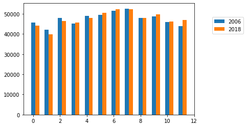

```python
data = {'2006':seasonal_df['Projected'].loc[:11], '2018':seasonal_df['Total Flights'].loc[12:]}

# set height of bar
bars1 = data['2006'].tolist()
bars2 = data['2018'].tolist()

# set width of bar
barWidth = 0.3

# Set position of bar on X axis
r1 = np.arange(len(bars1))
r2 = [x + barWidth for x in r1]

# Make the plot
plt.bar(r1, bars1,  width=barWidth, label='2006')
plt.bar(r2, bars2,  width=barWidth, label='2018')

# Create legend & Show graphic
plt.legend(bbox_to_anchor=(1.3, 0.8),loc='right')
plt.show()
```